# Proyecto Final

## Descripción del problema

Existen en total 53 regiones de transmisión en las que se realiza el intercambio de energía, de las cuales, 45 pertenecen al Sistema Interconectado Nacional (SIN), 4 pertenecen al Sistema de Baja California (BC) y 4 más al Sistema de Baja California Sur (BCS).

Para efectos del ejercicio sólo se consideraron las regiones de transmisión del SIN, ya que para los otros dos sistemas, la solución es trivial. (*Figura 1*)

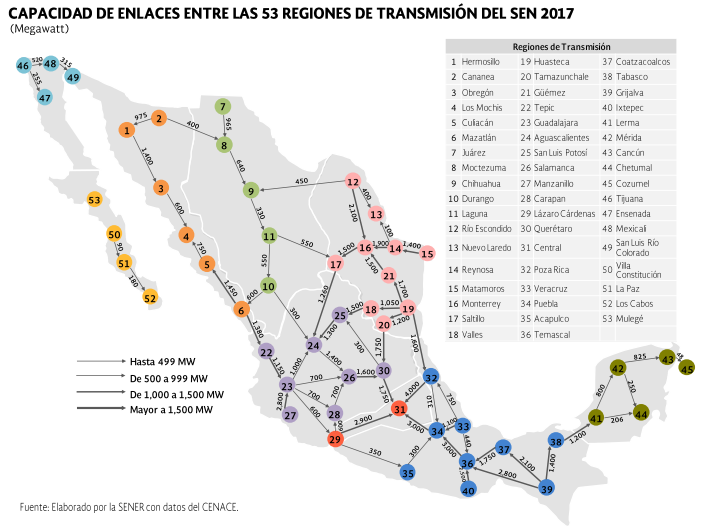

*Figura 1*

## Minimización de costos de flujo

En términos matemáticos, el problema se define como: \[ \begin{align*} \text{ minimizar } & \sum c_{ij}x_{ij} \\ \text{sujeto a } & \sum_{j = 1}^n x_{ij} - \sum_{k = 1}^n x_{ki} = b_i, & i=1, \ldots, n \\ & x_{ij} \geq 0, & i, j =1, \ldots, n \\ \end{align*} \] donde:

- \(n\) es el número de nodos en la red
- \(b_i\) representa la oferta disponible en el nodo \(i\)
- \(c_{ij}\) representa el costo de flujo unitario para el arco que va del nodo \(i\) al nodo \(j\)

**Algoritmo de puntos interiores - Método de barrera de Newton primal**

Función de barrera logarítmica: \(B(x, \mu) = c^Tx - \mu\sum_{i = 1}^{n} \text{ln} x_j\)

Algoritmo de puntos interiores:

Elegir \(\rho \in (0, 1)\) y \(\mu_0 > 0\) suficientemente grande.  
Elegir un punto \(x_0\) tal que \(A x_0 = b\) y \(x\geq 0\) (solución factible).  
**Para** \(k = 0, 1, . . .\) **hacer**  
\(\mu_k = \rho\mu_{k-1}\) Calcular la dirección de Newton \(p_B\)  
\(min_{\alpha} B(x_k, \mu_k)\), con \(x_k = x_{k-1} + \alpha p_B\), s.a. \(Ax_k = b\)  
\(x_k\leftarrow x_{k-1}+\alpha p_B\)  
\(k \leftarrow k + 1\)  
**Fin**

## Implementación

- *OR-Tools*: Software de Google de código abierto con rutinas para resolver problemas de optimización lineal, entera, y programación con restricciones (Glop linear solver).
- Python - Scipy: Modulo optimize de la librería scipy de python.
- Implementación manual: Se implementó manualmente el algoritmo de puntos interiores descrito previamente.

## Modelo

**Supuestos:**

- *Demanda es constante*: asumimos que la red tiene un flujo neto igual a 0, es decir, toda la electricidad que se genera se consume.
- *Flujo entre regiones*: se consideró el flujo desagregado al nivel de región (53). CENACE respondió que no cuenta con información desagregada a nivel nodo (2,046 nodos distribuidos en todo el país).
- *Costo*: PML para los nodos fuente (equivalente al costo de generación) y la tarifa de transmisión para el flujo entre la red.

## Esquema actual

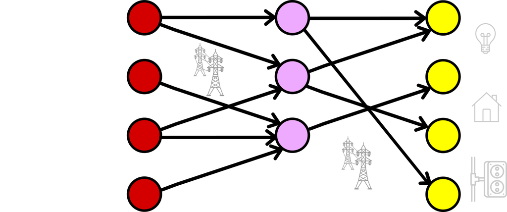

*Figura 2*

## Esquema propuesto

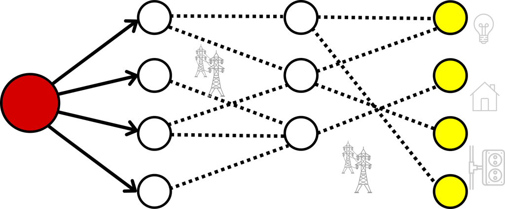

*Figura 3*

## Solución óptima

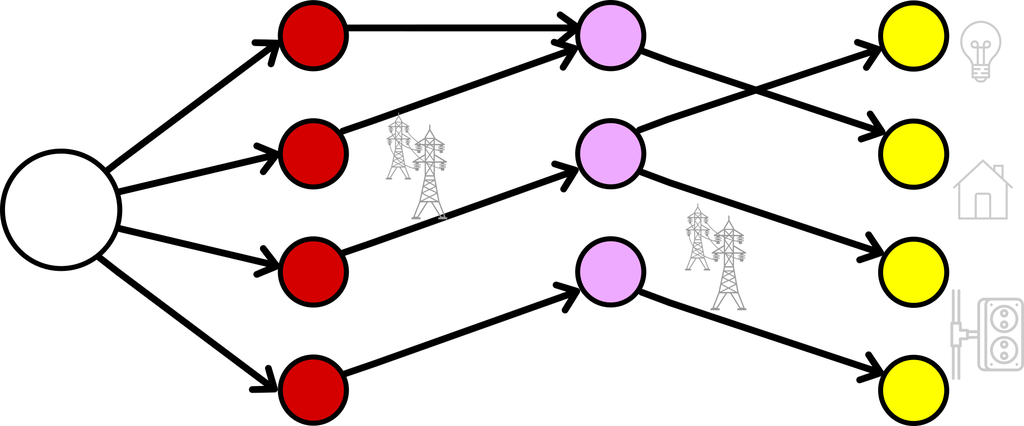

*Figura 4*

## Resultado

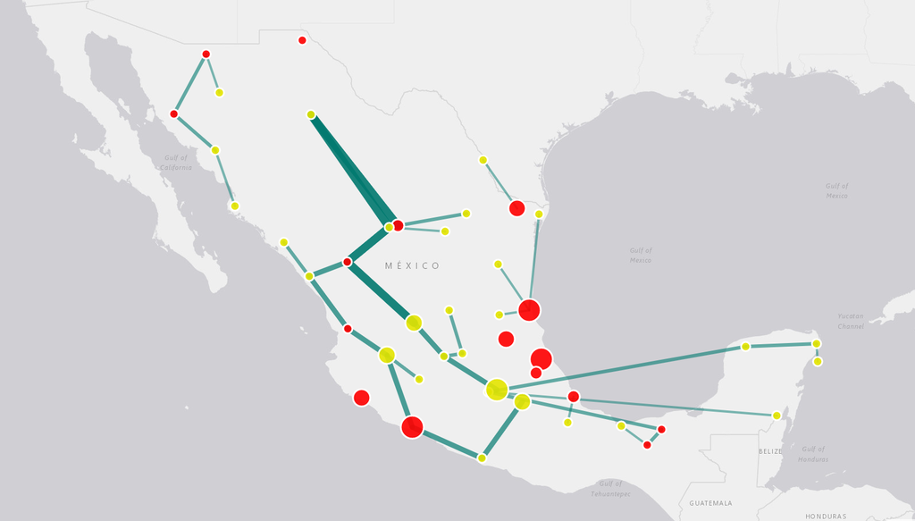

*Figura 5*